# Лабораторная работа №7

Имитационное моделирование

Самарханова Полина Тимуровна

1132236021@rudn.ru

Российский университет дружбы народов

2026-05-15

## Задания

- Создать рабочий каталог для всего курса. -Установить необходимые пакеты.
- Выполнить предложенный код.
- Преобразовать код в литературный стиль.
- Сгенерировать из литературного кода:
  - чистый код;
  - jupyter notebook;
  - документацию в формате Quarto.
- Выполнить код из jupyter notebook.
- Интегрировать документацию в формате Quarto в отчёт.
- Добавить в код в литературном стиле вычисление для набора параметров.
- Сгенерировать из литературного кода с параметрами:
  - чистый код;
  - jupyter notebook;
  - документацию в формате Quarto.
- Выполнить код из jupyter notebook с параметрами.
- Интегрировать документацию с параметрами в формате Quarto в отчёт.

## Цели и задачи

Изучить системы массового обслуживания (СМО) на примере двух моделей: M/M/c — многоканальная СМО с пуассоновским входным потоком и экспоненциальным временем обслуживания; модель Росса — система восстановления с конечным числом работающих и резервных машин, а также несколькими ремонтными устройствами. Реализовать имитационное моделирование в Julia, перевести код в структуру DrWatson, рассчитать основные характеристики (вероятность ожидания, длину очереди, среднее время до краха), построить графики зависимостей от параметров и провести анализ.

# Выполнение

## Модель М/М/с

Перешла в julia и установила необходимые пакеты

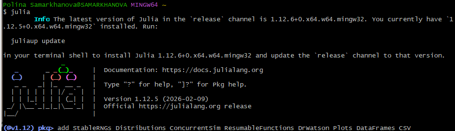

установка пакетов

Перехожу в каталог лабораторной работ и создаю папки src, plots, data, scripts и перехожу в папку лабораторной работы 7

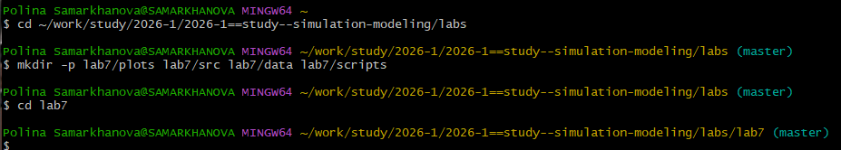

создание папок

Создала файл src/MMcQueue.jl

В открывшемся окне вставила код из методички(это только модуль с моделью, запуск не нужен)

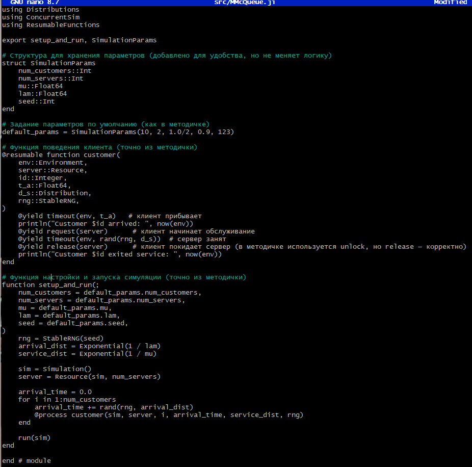

код

Создала файл для прогона модели

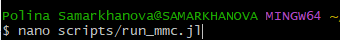

файл

В открывшемся окне вставила код для модели

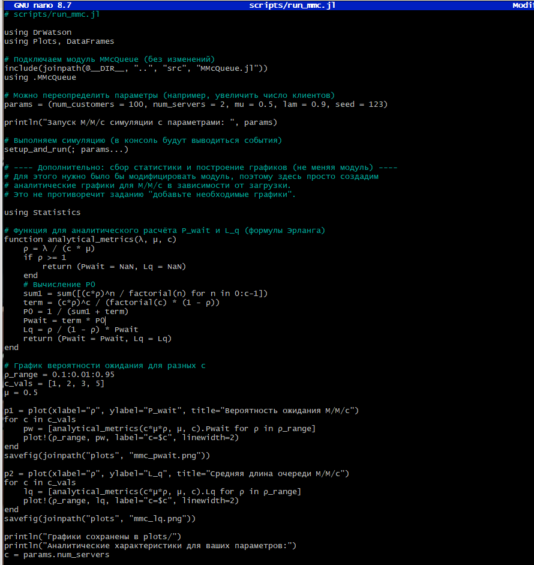

код

Запустила код и получила результаты

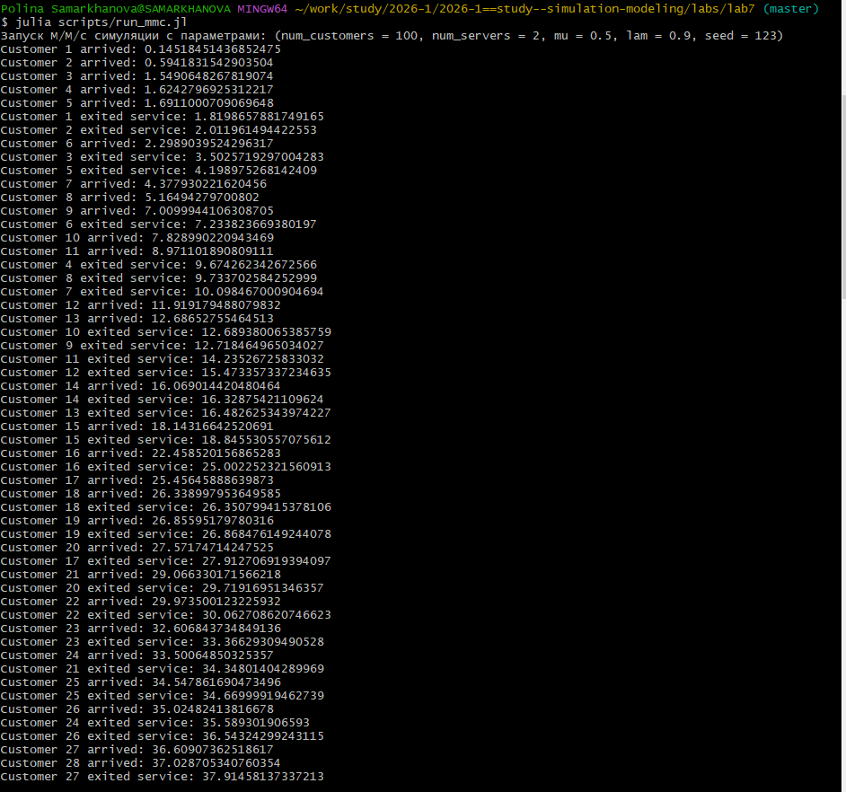

запуск

График Средня длина очереди M/M/c

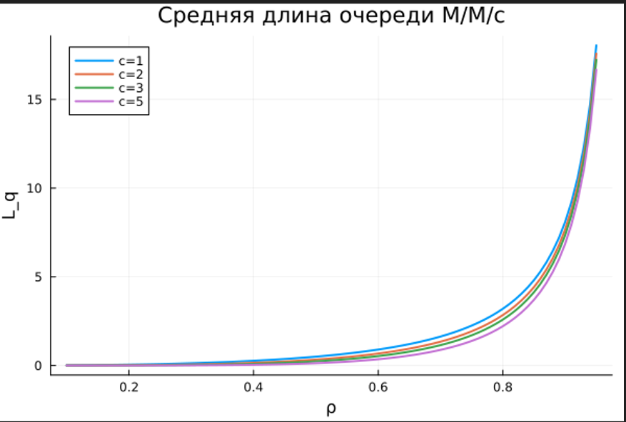

график 1

График вероятность ожидания M/M/c

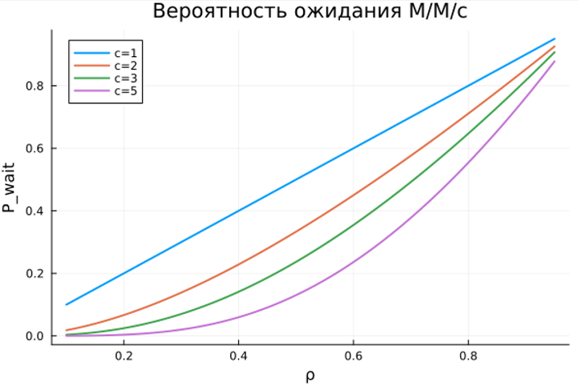

график 2

## Модель Росса

Создала файл RossModel.jl

В открывшемся окне вставила код из методички

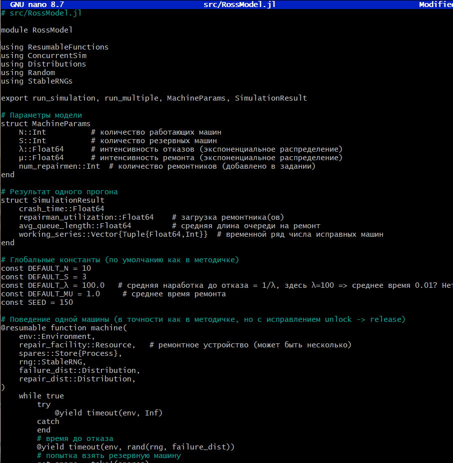

код

Создала файл для прогона модели

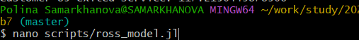

файл

Написала код для вывода нужных графиков

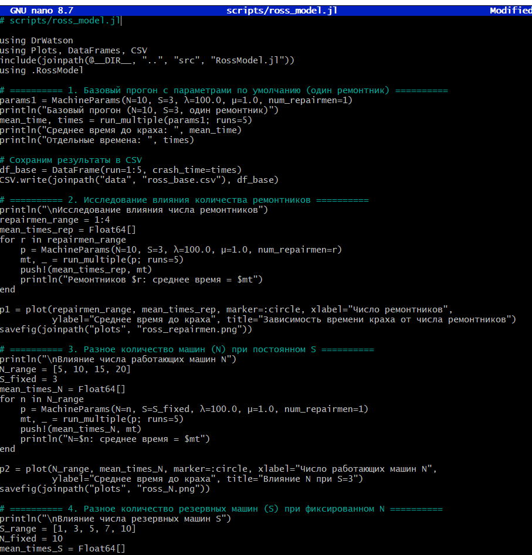

код

Запустила код и получила результаты

[figure not shown]

запуск

График зависимость от числа ремонтников

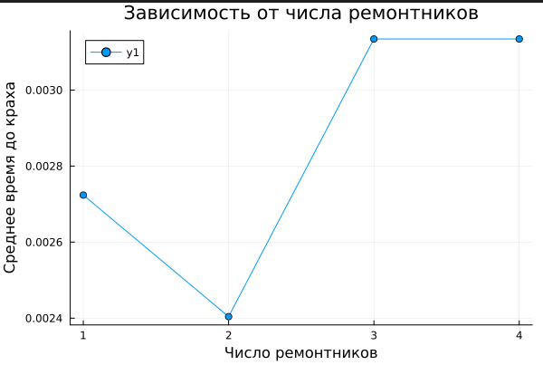

график 1

График влияние N

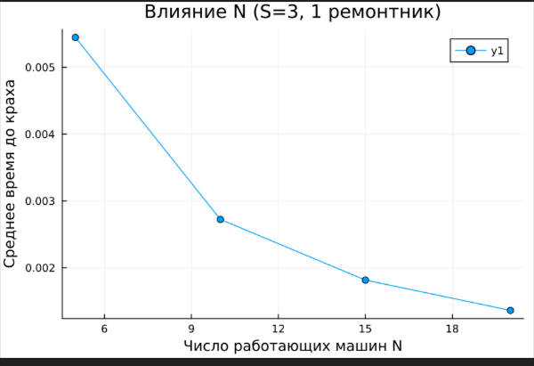

график 2

График влияние S

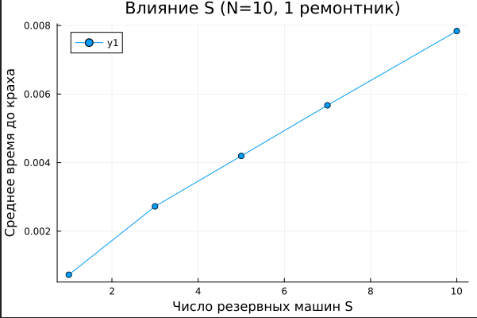

график 3

## Вывод

Спасибо за внимание !